# The Effect of Discounts on Retail Sales

A Machine Learning Analysis of Discount Strategy and Revenue Performance

Group 1 — Jake Evans, Mickyas Shawel, Aldo Naranjo, Luis Berumen, Tim Arana

IBM 6540 | Applied Machine Learning for Marketing | Cal Poly Pomona

August 12, 2026

# Introduction

## Problem Definition

Retailers face a persistent tension between offering discounts to drive volume and protecting per-transaction revenue. Key questions include:

- Do discounts actually increase units sold?
- At what point do discounts reduce net revenue?
- Which product categories and seasons respond differently to promotional pricing?
- Can a machine learning model reliably predict revenue outcomes from discount strategy?

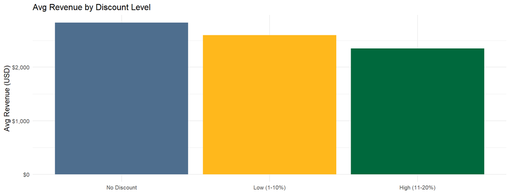

## Research Objectives

**Five research objectives guide our analysis:**

| RO | Member | Focus |
| --- | --- | --- |
| RO1 | Jake Evans | Seasonality & Holiday Effects |
| RO2 | Aldo Naranjo | Discount % vs. Units Sold |
| RO3 | Luis Berumen | Discounts & Sales Revenue |
| RO4 | Tim Arana | Sales Revenue Prediction |
| RO5 | Mickyas Shawel | Marketing Spend Interaction |

**Our overarching analytics objective:**

> Build supervised machine learning models that predict retail sales performance from discount strategy, marketing spend, product category, and seasonal features using 30,000 transaction-level records from 2022 to 2024.

## Why This Research Matters

- **For retailers:** Discounting is one of the most common promotional tools, but the margin impact is often unclear. Understanding the revenue consequences of different discount levels by category and season allows more precise promotional planning.
- **For marketing analysts:** Machine learning models that predict whether a transaction will generate above-median revenue give analysts a decision tool that goes beyond aggregate reporting.
- **For the field:** Most existing research treats discounts in isolation. This project examines discount effects alongside marketing spend, seasonality, holiday effects, and product category simultaneously.

# Population & Sample

## Population and Sample

**Population of interest:** Retail transactions across product categories in a multi-store, multi-region retail environment.

**Sample:** 30,000 transaction-level records from a Kaggle synthetic retail dataset designed to reflect realistic retail patterns (2022–2024).

**Note**

The group is using synthetic data for this analysis. Real transaction data was not available for this project. Findings should be interpreted in the context of the synthetic data generating process.

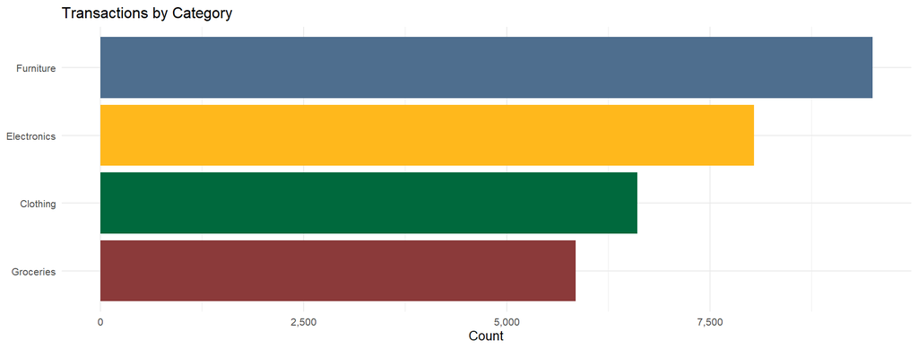

## Sample Characteristics

Key Dataset Summary Statistics

| Metric | Value |
| --- | --- |
| Total Transactions | 30,000 |
| Date Range | 2022-01-01 to 2024-01-01 |
| Avg Revenue | $2,749.51 |
| Median Revenue | $1,902.42 |
| Avg Discount % | 3% |
| Avg Units Sold | 6.2 |
| Avg Marketing Spend | $49.94 |
| Holiday Transactions % | 0.5% |

# RO1 — Jake Evans

## RO1: Model Fitting

```r
set.seed(617)

ro1_data <- retail |>
  select(revenue, season, day, holiday, category, discount_group, mktg_spend)

split <- initial_split(ro1_data, prop = 0.80, strata = revenue)
train <- training(split)
test  <- testing(split)

rec <- recipe(revenue ~ ., data = train) |>
  step_novel(all_nominal_predictors()) |>
  step_unknown(all_nominal_predictors()) |>
  step_dummy(all_nominal_predictors()) |>
  step_zv(all_predictors()) |>
  step_normalize(all_numeric_predictors())

en_spec <- linear_reg(penalty = tune(), mixture = tune()) |>
  set_engine("glmnet") |>
  set_mode("regression")

en_wf <- workflow() |> add_recipe(rec) |> add_model(en_spec)

folds   <- vfold_cv(train, v = 5, strata = revenue)
en_grid <- grid_regular(penalty(), mixture(), levels = 5)

en_tuned <- tune_grid(en_wf, resamples = folds, grid = en_grid,
                       metrics = metric_set(rmse, rsq))
best_en  <- select_best(en_tuned, metric = "rmse")
en_final <- finalize_workflow(en_wf, best_en) |> fit(train)

rf_spec <- rand_forest(trees = 300, mtry = 4, min_n = 10) |>
  set_engine("ranger", importance = "impurity") |>
  set_mode("regression")

rf_wf  <- workflow() |> add_recipe(rec) |> add_model(rf_spec)
rf_fit <- fit(rf_wf, data = train)
```

## RO1: Model Evaluation

| Model | RMSE | R-squared |
| --- | --- | --- |
| Elastic Net | $2,509.31 | 0.090 |
| Random Forest | $2,494.50 | 0.101 |

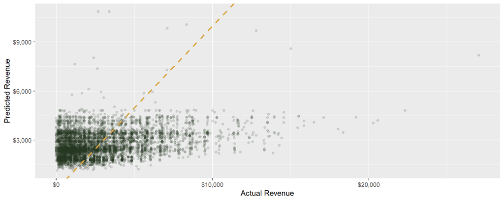

## RO1: Variable Importance

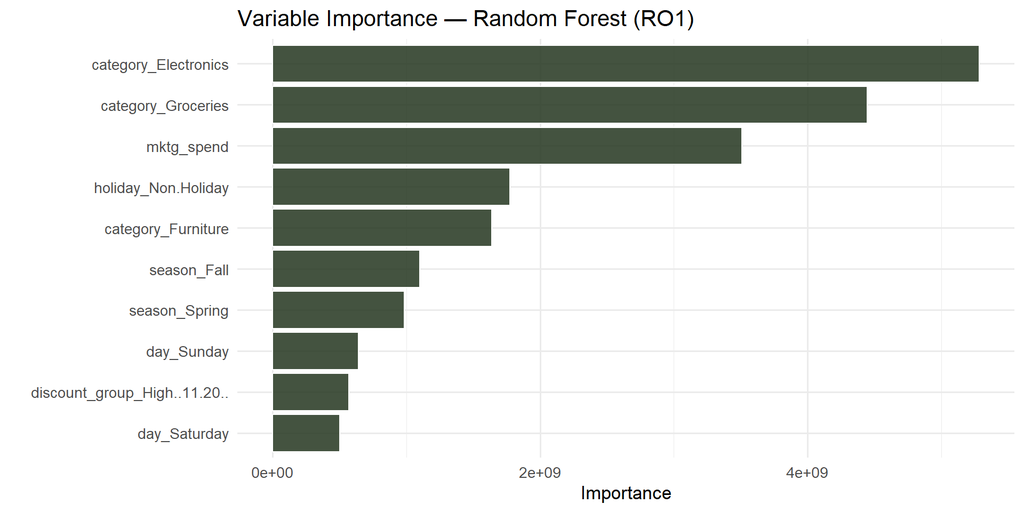

## RO1: Summary Findings

**Business recommendation:**

> Use seasonal and holiday timing as a secondary lever layered on top of category- and discount-driven strategy, not as a standalone driver of revenue planning.

# RO2 — Aldo Naranjo

## RO2: Do Discounts Drive Unit Sales?

**Analytics Objective:** Predict whether a retail transaction generates above- or below-median revenue (`high` vs. `low`) using discount percentage, marketing spend, units sold, product category, season, and holiday status.

**ML Methods Used:**

- Lasso Logistic Regression (baseline)
- Tuned Decision Tree
- **Random Forest (primary)**
- XGBoost

**Evaluation Metric:** ROC AUC (classification)

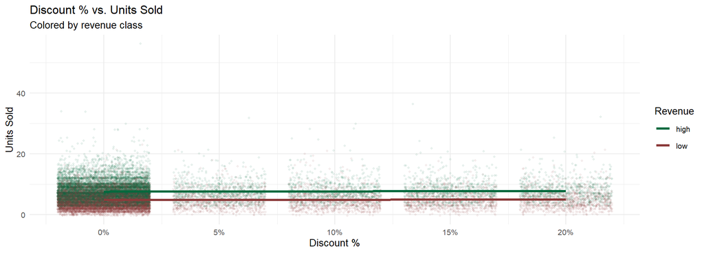

## RO2: Data Wrangling & EDA

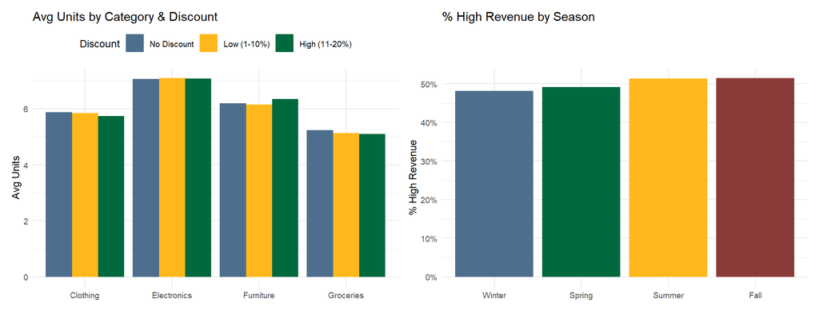

## RO2: Model Fitting

```r
# Train/test split — stratified on outcome
set.seed(617)
retail_ml <- retail |> select(-location, -date, -revenue, -store_id, -product_id)
split <- initial_split(retail_ml, prop = 0.80, strata = high_revenue)
train <- training(split)
test  <- testing(split)

# Recipe
rec <- recipe(high_revenue ~ ., data = train) |>
  step_impute_median(all_numeric_predictors()) |>
  step_novel(all_nominal_predictors()) |>
  step_unknown(all_nominal_predictors()) |>
  step_zv(all_predictors())

# Random Forest specification
rf_spec <- rand_forest(trees = 300, mtry = 4, min_n = 20) |>
  set_engine("ranger", importance = "impurity") |>
  set_mode("classification")

rf_wf  <- workflow() |> add_recipe(rec) |> add_model(rf_spec)
rf_fit <- fit(rf_wf, data = train)
```

## RO2: Model Evaluation

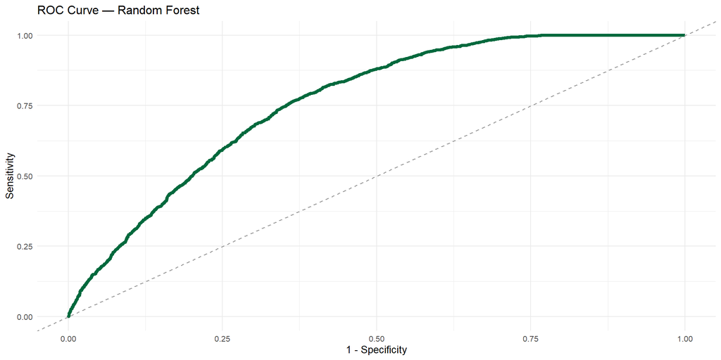

Test Set Metrics

| Metric | Value |
| --- | --- |
| accuracy | 0.699 |
| sens | 0.755 |
| spec | 0.643 |
| roc_auc | 0.761 |

## RO2: Variable Importance

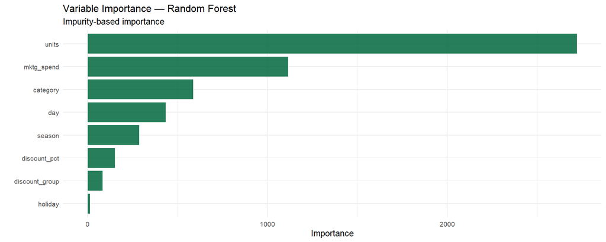

## RO2: Summary Findings

**Business recommendation:**

> Prioritize marketing spend and volume-driving promotions over deep discount rates. High discounts reduce per-transaction margin without reliably moving the revenue class needle, especially in lower-margin categories like Groceries and Clothing.

# RO3 — Luis Berumen

## RO3: Do Discounts Increase Sales Revenue?

**Analytics Objective:** Examine the relationship between discount percentage and Sales Revenue using regression models. Units Sold, Product Category, Marketing Spend, season, day of week, and holiday status are also included to determine whether Discount Percentage is an important predictor of Sales Revenue.

### ML Methods Used

- OLS Linear Regression (baseline)
- Ridge Regression
- Lasso Regression
- **Tuned Elastic Net (primary)**
- 10-fold cross-validation for model comparison

**Evaluation Metrics:** RMSE, MAE, and R-squared

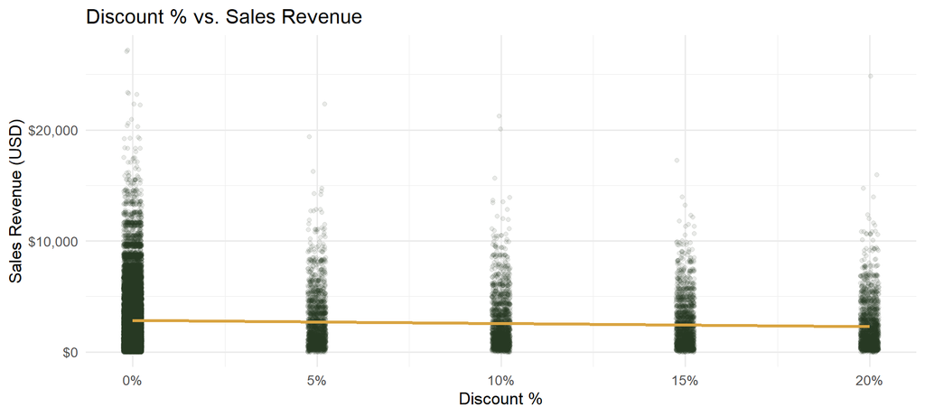

## RO3: Data Wrangling & EDA

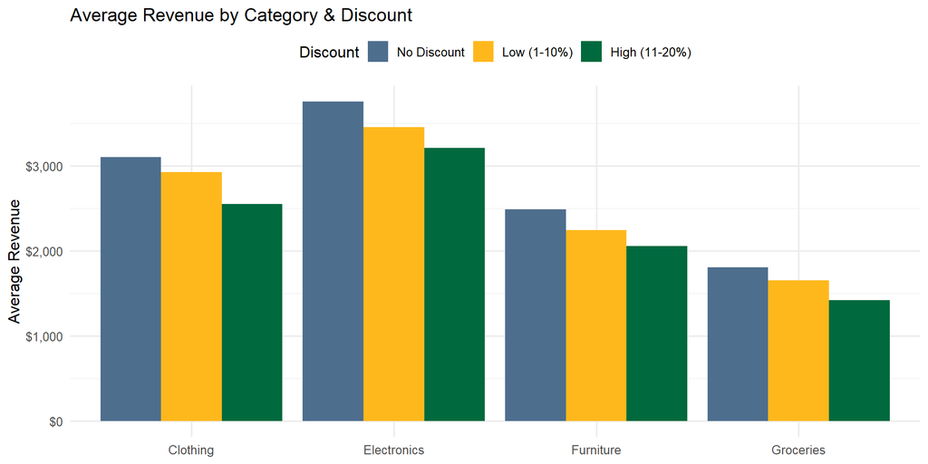

Revenue by Discount Group

| discount_group | Transactions | Avg Revenue | Total Revenue |
| --- | --- | --- | --- |
| No Discount | 22846 | $2,834.86 | $64,765,282 |
| Low (1-10%) | 3608 | $2,599.89 | $9,380,408 |
| High (11-20%) | 3546 | $2,351.83 | $8,339,598 |

## RO3: Model Fitting

```r
set.seed(617)

ro3_data <-
  retail |>
  select(
    revenue,
    discount_pct,
    units,
    mktg_spend,
    category,
    day,
    holiday,
    season
  )

ro3_split <-
  initial_split(
    ro3_data,
    prop = 0.80,
    strata = revenue
  )

ro3_train <- training(ro3_split)
ro3_test <- testing(ro3_split)

ro3_rec <-
  recipe(
    revenue ~ .,
    data = ro3_train
  ) |>
  step_impute_median(
    all_numeric_predictors()
  ) |>
  step_novel(
    all_nominal_predictors()
  ) |>
  step_unknown(
    all_nominal_predictors()
  ) |>
  step_dummy(
    all_nominal_predictors()
  ) |>
  step_normalize(
    all_numeric_predictors()
  ) |>
  step_zv(
    all_predictors()
  )

set.seed(617)

ro3_folds <-
  vfold_cv(
    ro3_train,
    v = 10,
    strata = revenue
  )

ro3_ols_wf <-
  workflow() |>
  add_recipe(ro3_rec) |>
  add_model(
    linear_reg() |>
      set_engine("lm")
  )

ro3_ridge_wf <-
  workflow() |>
  add_recipe(ro3_rec) |>
  add_model(
    linear_reg(
      penalty = 0.1,
      mixture = 0
    ) |>
      set_engine("glmnet")
  )

ro3_lasso_wf <-
  workflow() |>
  add_recipe(ro3_rec) |>
  add_model(
    linear_reg(
      penalty = 0.1,
      mixture = 1
    ) |>
      set_engine("glmnet")
  )

ro3_en_spec <-
  linear_reg(
    penalty = tune(),
    mixture = tune()
  ) |>
  set_engine("glmnet")

ro3_en_wf <-
  workflow() |>
  add_recipe(ro3_rec) |>
  add_model(ro3_en_spec)

ro3_grid <-
  grid_regular(
    penalty(range = c(-4, 0)),
    mixture(),
    levels = c(8, 5)
  )

ro3_en_tuned <-
  tune_grid(
    ro3_en_wf,
    resamples = ro3_folds,
    grid = ro3_grid,
    metrics = metric_set(
      rmse,
      mae,
      rsq
    )
  )

ro3_best <-
  select_best(
    ro3_en_tuned,
    metric = "rmse"
  )

ro3_final_wf <-
  finalize_workflow(
    ro3_en_wf,
    ro3_best
  )

ro3_final_fit <-
  fit(
    ro3_final_wf,
    data = ro3_train
  )
```

## RO3: Model Evaluation

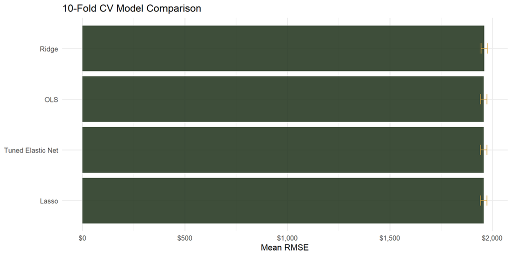

Final Test Metrics

| Metric | Value |
| --- | --- |
| RMSE | $2,003.40 |
| MAE | $1,492.63 |
| RSQ | 0.421 |

## RO3: Feature Importance

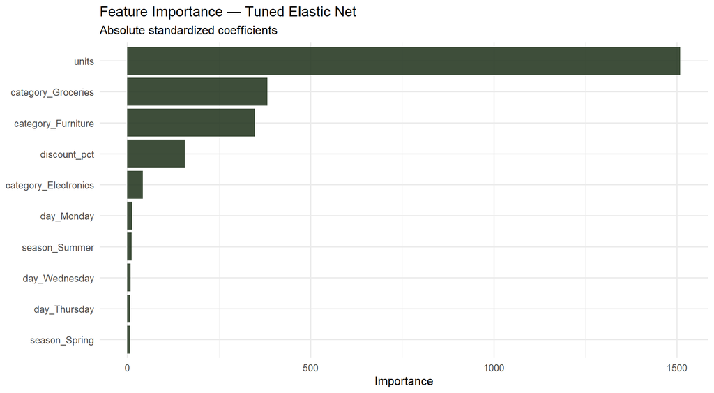

## RO3: Summary Findings

### What This AO Answers

1. RO3 examines whether Discount Percentage is related to Sales Revenue.
2. Discount Percentage is evaluated with Units Sold, Marketing Spend, Product Category, season, day, and holiday status.
3. OLS, Ridge, Lasso, and Elastic Net are compared using 10-fold cross-validation.
4. Feature importance evaluates how useful Discount Percentage is relative to the other predictors.

### Business Recommendation

> Retailers should evaluate Discount Percentage together with Units Sold, Marketing Spend, Product Category, and timing rather than using discounts alone when making revenue decisions.

**Final interpretation:** The final RMSE, MAE, R-squared, and feature-importance results determine how well the model predicts Sales Revenue and how important Discount Percentage is relative to the other variables.

# RO4 — Tim Arana

## RO4: Predicting Sales Revenue

### Analytics Objective

Predict **Sales Revenue (USD)** and evaluate how **Product Category** and other retail characteristics contribute to revenue predictions.

**Machine Learning Task**

- Supervised learning
- Regression
- Outcome: Sales Revenue (USD)
- 80% training / 20% testing
- 10-fold cross-validation

### Models Compared

1. Lasso Regression
2. Tuned Decision Tree
3. Random Forest
4. XGBoost

### Key Predictors

- Units Sold
- Discount Percentage
- Marketing Spend
- Product Category
- Store Location
- Day of the Week
- Holiday Effect

## RO4: Model Comparison

### 10-Fold CV Results

**XGBoost: 1,963.20**

Decision Tree: 1,973.09

Lasso Regression: 1,978.16

Random Forest: 2,056.74

*Lower RMSE = better prediction*

### Best-Performing Model

**XGBoost** achieved the lowest average cross-validated RMSE.

- Only **9.89 RMSE** better than Decision Tree
- Difference was **less than one standard error**
- The two leading models therefore performed similarly

### Takeaway

**XGBoost ranked first, but its predictive advantage over the simpler Decision Tree was modest.**

## RO4: Model Interpretation

### Variable Importance & SHAP

- **Units Sold** was the dominant predictor.
- **Product Category** provided additional predictive value.
- **Groceries** and **Furniture** were among the strongest category features.
- Discount Percentage and Marketing Spend had smaller contributions.

### Partial Dependence

- Predicted revenue generally increased as **Units Sold** increased.
- The relationship was **positive but nonlinear**.
- XGBoost captured changes and plateaus in predicted revenue.

### Takeaway

**Sales volume drives revenue predictions, while Product Category provides additional information.**

## RO4: Findings & Recommendation

### Key Findings

- **XGBoost** achieved the lowest cross-validated RMSE.
- Its advantage over the Decision Tree was modest.
- **Units Sold** was the dominant predictor of Sales Revenue.
- **Product Category** provided additional predictive value, especially Groceries and Furniture.

### Business Recommendation

- Use **XGBoost** when predictive performance is the priority.
- Consider the **Decision Tree** when interpretability is more important.
- Monitor sales volume closely.
- Use **category-specific merchandising and promotional strategies**.

### Live Model

[Retail Sales Revenue Predictor](https://tarana7.shinyapps.io/W10-ML-Deployment/)

# RO5 — Mickyas Shawel

## RO5: Marketing Spend × Discount Interaction

**Research Objective**

Determine whether marketing spend strengthens the effect of discount percentage on retail sales revenue.

**Final Model**

`Revenue ~ Discount + Marketing Spend + Discount × Marketing Spend`

**Key Result**

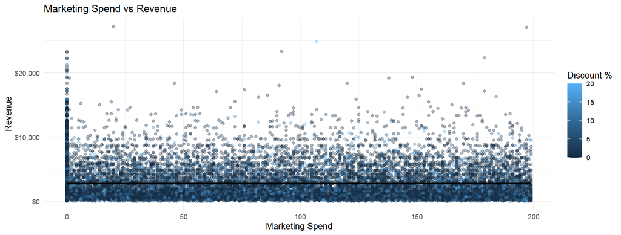

## RO5: Interaction Analysis

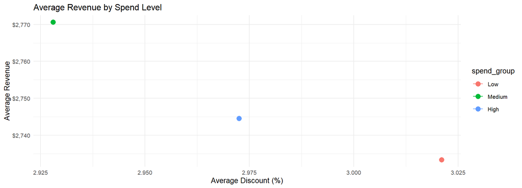

# Conclusion

## Key Findings

**Across all research objectives, our analysis found:**

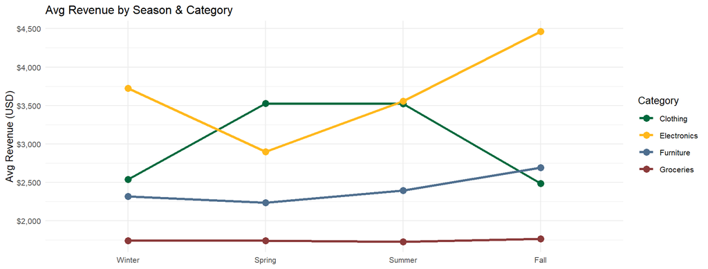

## Limitations and Future Research

**Current limitations:**

- **Synthetic data:** All findings are based on a Kaggle dataset designed for analytics practice, not real transaction data. Results may not generalize to actual retail environments.
- **No causal inference:** Our models are predictive, not causal. We cannot establish that discounts cause revenue changes, only that they are associated with them.
- **Missing variables:** Customer-level features (loyalty, lifetime value, demographics) are absent and would likely improve model performance.
- **Static model:** The deployed model does not retrain on new data. Real-world drift in discount response patterns would degrade performance over time.

**Directions for future research:**

- Collect real transaction data with customer-level identifiers to enable customer lifetime value modeling
- Apply causal inference methods (e.g., difference-in-differences, instrumental variables) to isolate the true causal effect of discounts on revenue
- Build a full MLOps pipeline using `vetiver` and `pins` to automate model retraining as new data arrives
- Explore segmentation-based discount optimization: different optimal discount rates for different customer and product segments

# Appendix

## Appendix

**GitHub Repository:**

https://github.com/mjshawell/IBM-6540-Group-Project

**Deployed Model (Shiny App — RO2):**

https://k9wfby-aldo-naranjo.shinyapps.io/retail-revenue-predictor/

**Dataset:**

Kaggle Synthetic Retail Sales Dataset  
30,000 transactions | 2022–2024  
4 product categories | 11 variables

**Group Members:**

- Jake Evans
- Mickyas Shawel
- Aldo Naranjo
- Luis Berumen
- Tim Arana

**Course:** IBM 6540 — Applied Machine Learning for Marketing  
**Institution:** Cal Poly Pomona | Summer 2026

## Thank You

**Group 1 — IBM 6540**

Jake Evans | Mickyas Shawel | Aldo Naranjo | Luis Berumen | Tim Arana

*Cal Poly Pomona | Summer 2026*

**Questions?**